# Locus boundaries from the association profile or LD blocks, against distance (#409)

Published

November 6, 2026

## The question

#403 found that distance pruning (cM or bp) tracks per-Analysis clump counts (C1) and is far less density-sensitive than raw hit counts (C2), but that a genetic map adds nothing over a bp window (C3). Its per-lead disagreement with r² 0.01 clumping concentrates at strong peaks. This report tests two rules that take their locus boundaries from the data rather than from a fixed distance, on #403’s Analyses, shared set and clumps, judged by the same count criteria:

- **Peak prominence on the association profile.** Two 5×10⁻⁸ rows belong to one locus unless the |z| profile between them falls into a valley.
- **One lead per LD block.** The lead is the strongest row in each EUR LD block.

## Result

- **C1 and C2.** Met by B 50 kb, f 0.25; B 50 kb, f 0.5; B 50 kb, f 0.75; B 50 kb, fixed T 0; LD blocks (EUR). C1 alone fails for B 10 kb, f 0.25; B 10 kb, fixed T 0; C2 fails for B 10 kb, f 0.25; B 10 kb, f 0.5; B 10 kb, f 0.75; B 10 kb, fixed T 0.
- **C3 against bp-only.** At W 10 Mb, #403’s named point: none. At any W: B 50 kb, f 0.75 at W 1 Mb.
- **Valleys.** Of the sampled no-row valleys, 13.5% at B 10 kb; 0.5% at B 50 kb; 7.0% pooled are gaps in coverage rather than low |z|; the stop rule trips for none.

## The rules

**Prominence.**

- Profile: the Analysis’s observed rows in the 5e-4 Top-Hit tier, every one of them, including rows outside the shared set (off the panel, for example).
- Envelope: per chromosome, bins of B bp fixed from position 0 (bin = position // B); a bin’s envelope is the largest |z| among the profile’s rows in it, and 0 when it holds none.
- Col: between two rows on one chromosome, the lowest envelope over the bins from one row’s bin to the other’s, both included.
- Order: abs_z descending, then Store Variant Index ascending (the Locus Lead ranking).
- Join: a candidate joins the strongest (first accepted) lead on its chromosome at most 10,000,000 bp away whose col is above the candidate’s threshold; otherwise it becomes a lead.
- Thresholds: relative, threshold = f x the candidate’s own |z|; fixed, threshold = T; with T = 0, a chain of bins that all hold a tier row.
- Grid: B in 10 kb, 50 kb; thresholds f 0.25, f 0.5, f 0.75, fixed T 0.

**LD blocks** (1,357 EUR blocks of `ld_regions_hg38.tsv`).

- Blocks: the rows of the LD-region file for the ancestry, each half-open [start, end), so a row at a shared endpoint belongs to the block that starts there.
- Lead: the block’s strongest row: abs_z descending, then Store Variant Index ascending.
- Outside every block: a row outside every block belongs to the stretch between blocks it falls in (before a chromosome’s first block, between two, after its last, or the whole of a chromosome without blocks); each stretch holds one lead, and those rows and stretches are counted.

## The inputs, checked against #403’s

The 37 Analyses #403 swept, from its selection (sha256 `04b0d3c03933`); the 3 it left out below its shared-set floor are left out here too (GCST90704633, GCST90475609, GCST90477870).

- **Profile.** Two Top-Hit Queries per Analysis at 5e-4: the observed-only one, which is the profile, and an unrestricted one that counts the imputed rows, so the read is checked complete. The profile holds 7,951,637 observed rows in all, at most 1,376,991 (GCST90476460). Every Analysis’s tier was read and used. Of these rows, 1,806,262 are candidates (at 5e-8, in the shared set), 158,334 are at 5e-8 but outside the shared set (off the panel, for example), and 5,987,041 are below it. All of them shape the profile.
- **Shared set.** The rule: the candidates’ shared set must equal the shared set of the 5e-8 tier, read now with #403’s read_tier and built with its build_shared_set: the same row count and sha256 of Store, Analysis and sorted Store Variant Indices. Both must reproduce #403’s committed summaries: its accounting, its HapMap3 row counts and its distance rules’ records. #403 committed no digest, so the digest published is of the current reads, and matches_403_summaries says only that the summaries are reproduced. It held for 37 of 37 Analyses; the sweep stops on any other.
- **Clumps and distance rules.** plink2 at r² 0.01 on that shared set. #403’s distance rules (bp only, W 0.25 Mb; bp only, W 1 Mb; bp only, W 2.5 Mb; bp only, W 10 Mb; D 0.5 cM, W 1 Mb) were recomputed on it and matched #403’s committed per-Analysis records exactly, leads, splits, lost signals, |z| bands and HapMap3 leads alike, before any new rule was scored.

## Are the empty valleys low |z|, or gaps in coverage?

A bin with no tier row has envelope 0 whether the Analysis’s |z| there is below the tier’s floor or its cells are missing. Every split the prominence rule makes is classed by its valley bin.

Splits pooled over the Analyses, by their valley, in the full profile and on HapMap3 alone.

| rule | splits | no tier row | low \|z\| | HapMap3: splits | no tier row | low \|z\| |
| --- | --- | --- | --- | --- | --- | --- |
| B 10 kb, f 0.25 | 25,994 | 25,870 | 124 | 39,079 | 38,976 | 103 |
| B 10 kb, f 0.5 | 28,336 | 26,003 | 2,333 | 41,110 | 39,152 | 1,958 |
| B 10 kb, f 0.75 | 42,480 | 26,728 | 15,752 | 50,118 | 39,937 | 10,181 |
| B 10 kb, fixed T 0 | 25,862 | 25,862 | 0 | 38,971 | 38,971 | 0 |
| B 50 kb, f 0.25 | 8,934 | 8,896 | 38 | 11,657 | 11,631 | 26 |
| B 50 kb, f 0.5 | 9,916 | 8,978 | 938 | 12,071 | 11,653 | 418 |
| B 50 kb, f 0.75 | 15,100 | 9,213 | 5,887 | 14,696 | 11,758 | 2,938 |
| B 50 kb, fixed T 0 | 8,890 | 8,890 | 0 | 11,629 | 11,629 | 0 |

The no-row valleys were then checked against the Store’s Z values. Sample: per bin width B, up to 200 of the distinct (Store, Analysis, chromosome, bin) valleys with no tier row, over every prominence rule at full density, drawn by random.Random(409).sample from their sorted list (33,248 distinct no-row valleys in all). Cells: every variant of the Store’s Variant Index in the bin [bin x B, (bin + 1) x B - 1], read for the Analysis through the query facade’s lookup. A valley is *low |z|* when the bin holds at least one observed cell (all below the tier’s floor, |z| < 3.4808); it is a gap when the bin holds Store variants but none with an observed cell for the Analysis (missing, or imputed only), or when the Store’s Variant Index holds no variant in the bin.

| sample | valleys | low \|z\| | missing cells | no variant | share gap | stop rule trips | cells | observed | imputed | missing |
| --- | --- | --- | --- | --- | --- | --- | --- | --- | --- | --- |
| B 10 kb | 200 | 173 | 25 | 2 | 13.5% | no | 25,462 | 6,079 | 2,499 | 16,884 |
| B 50 kb | 200 | 199 | 0 | 1 | 0.5% | no | 132,480 | 35,964 | 8,597 | 87,919 |
| pooled | 400 | 372 | 25 | 3 | 7.0% | no | 157,942 | 42,043 | 11,096 | 104,803 |

Most cells in the sampled bins are missing for their Analysis: 104,803 of 157,942 (66.4%), with 42,043 observed and 11,096 imputed. A valley counts as low |z| on one observed cell, so a bin read mostly from missing cells still counts.

Stop rule: more than half of a sample’s valleys are gaps: the profile cannot tell a valley from a gap in coverage. It trips for no sample: the profile’s empty valleys are low |z|, not gaps in coverage.

## Count criteria

The criteria are #403’s, with its wording; C3 is read against the bp-only window at each W.

- **C1, rank. Spearman rho(Locus Leads, r2 0.01 index variants) over the swept Analyses is >= 0.95.**
- **C2, density. For each swept Analysis, restrict the shared set to HapMap3 variants and recompute the leads at every (D, W) and bp-only; no re-clumping. Density ratio = leads(HM3) / leads(full). C2 holds when the median ratio over Analyses is in [0.8, 1.25] and its median |log2| is at most half that of the same ratio for raw row counts (rows(HM3) / rows(full)).** Here for C2 the HapMap3 restriction applies to the 5e-4 profile as well as to the 5e-8 candidates: both are cut to HapMap3 ALIDs before a rule runs; the raw-row ratio C2 compares with is #403’s, from the same shared set.
- **C3, cM against bp-only, at the same W. cM adds value when its best D improves on bp-only by at least 0.01 in rho (C1) or by at least 0.1 in median |log2 density ratio| (C2), without being worse on the other by more than those margins.** Reading: a rule has no W, so at each W of #403’s grid it is compared with that W’s bp-only window: C3 holds when it improves on bp-only by at least one margin and is worse on neither by more than its margin (#403’s test); W 10 Mb is #403’s named point.

### C1 and C2

The raw rows keep a median 2.508 in |log2| on HapMap3, so C2 asks the leads’ median |log2| to be at most 1.254.

| rule | ρ | C1 | median ratio | median \|log2\| | C2 | Analyses with no HapMap3 lead | leads (full) | leads (HapMap3) | lost to density |
| --- | --- | --- | --- | --- | --- | --- | --- | --- | --- |
| B 10 kb, f 0.25 | 0.942 | no | 1.684 | 0.794 | no | 0 | 29,091 | 42,060 | 8.5% |
| B 10 kb, f 0.5 | 0.952 | yes | 1.600 | 0.725 | no | 0 | 31,427 | 44,090 | 8.8% |
| B 10 kb, f 0.75 | 0.980 | yes | 1.274 | 0.467 | no | 0 | 45,563 | 53,096 | 7.7% |
| B 10 kb, fixed T 0 | 0.945 | no | 1.686 | 0.789 | no | 0 | 28,960 | 41,952 | 8.4% |
| B 50 kb, f 0.25 | 0.966 | yes | 1.000 | 0.127 | yes | 0 | 12,057 | 14,650 | 2.2% |
| B 50 kb, f 0.5 | 0.972 | yes | 1.000 | 0.134 | yes | 0 | 13,018 | 15,062 | 2.3% |
| B 50 kb, f 0.75 | 0.984 | yes | 0.962 | 0.098 | yes | 0 | 18,193 | 17,685 | 4.3% |
| B 50 kb, fixed T 0 | 0.966 | yes | 1.000 | 0.127 | yes | 0 | 12,020 | 14,624 | 2.2% |
| LD blocks (EUR) | 0.990 | yes | 0.863 | 0.213 | yes | 0 | 10,957 | 9,621 | 12.2% |
| #403: bp only, W 10 Mb | 0.982 | yes | 0.946 | 0.079 | yes | 0 | 3,712 | 3,532 | 4.8% |
| #403: D 0.5 cM, W 1 Mb | 0.994 | yes | 0.854 | 0.227 | yes | 0 | 13,951 | 11,819 | 15.3% |
| #403: bp only, W 0.25 Mb | 0.996 | yes | 0.818 | 0.290 | yes | 0 | 21,463 | 17,275 | 19.5% |
| #403: bp only, W 1 Mb | 0.993 | yes | 0.864 | 0.212 | yes | 0 | 11,861 | 10,259 | 13.5% |
| #403: bp only, W 2.5 Mb | 0.986 | yes | 0.902 | 0.149 | yes | 0 | 8,057 | 7,279 | 9.7% |

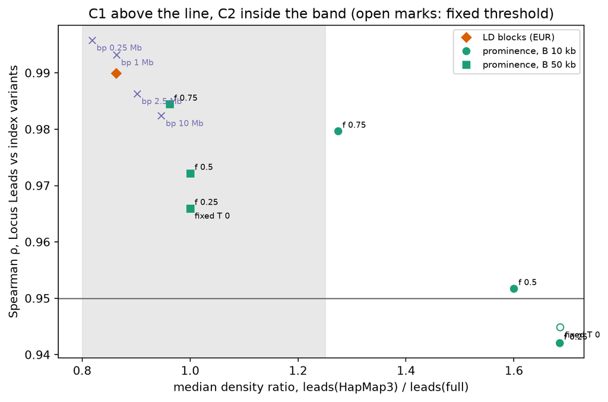

### C3: against bp-only at each W

Δρ is the rule’s ρ minus bp-only’s; Δ|log2| is bp-only’s median |log2| minus the rule’s, so positive is better for both.

The margins are 0.01 on ρ and 0.1 on |log2|. W 10 Mb is #403’s named point.

| rule | W | Δρ | Δ\|log2\| | C3 holds |
| --- | --- | --- | --- | --- |
| B 10 kb, f 0.25 | 0.25 Mb | -0.054 | -0.504 | no |
| B 10 kb, f 0.25 | 1 Mb | -0.051 | -0.582 | no |
| B 10 kb, f 0.25 | 2.5 Mb | -0.044 | -0.644 | no |
| B 10 kb, f 0.25 | 10 Mb | -0.040 | -0.714 | no |
| B 10 kb, f 0.5 | 0.25 Mb | -0.044 | -0.435 | no |
| B 10 kb, f 0.5 | 1 Mb | -0.041 | -0.513 | no |
| B 10 kb, f 0.5 | 2.5 Mb | -0.035 | -0.575 | no |
| B 10 kb, f 0.5 | 10 Mb | -0.031 | -0.645 | no |
| B 10 kb, f 0.75 | 0.25 Mb | -0.016 | -0.177 | no |
| B 10 kb, f 0.75 | 1 Mb | -0.014 | -0.255 | no |
| B 10 kb, f 0.75 | 2.5 Mb | -0.007 | -0.318 | no |
| B 10 kb, f 0.75 | 10 Mb | -0.003 | -0.387 | no |
| B 10 kb, fixed T 0 | 0.25 Mb | -0.051 | -0.500 | no |
| B 10 kb, fixed T 0 | 1 Mb | -0.048 | -0.578 | no |
| B 10 kb, fixed T 0 | 2.5 Mb | -0.041 | -0.640 | no |
| B 10 kb, fixed T 0 | 10 Mb | -0.038 | -0.710 | no |
| B 50 kb, f 0.25 | 0.25 Mb | -0.030 | +0.162 | no |
| B 50 kb, f 0.25 | 1 Mb | -0.027 | +0.084 | no |
| B 50 kb, f 0.25 | 2.5 Mb | -0.020 | +0.022 | no |
| B 50 kb, f 0.25 | 10 Mb | -0.016 | -0.048 | no |
| B 50 kb, f 0.5 | 0.25 Mb | -0.024 | +0.156 | no |
| B 50 kb, f 0.5 | 1 Mb | -0.021 | +0.078 | no |
| B 50 kb, f 0.5 | 2.5 Mb | -0.014 | +0.015 | no |
| B 50 kb, f 0.5 | 10 Mb | -0.010 | -0.054 | no |
| B 50 kb, f 0.75 | 0.25 Mb | -0.011 | +0.191 | no |
| B 50 kb, f 0.75 | 1 Mb | -0.009 | +0.113 | yes |
| B 50 kb, f 0.75 | 2.5 Mb | -0.002 | +0.051 | no |
| B 50 kb, f 0.75 | 10 Mb | +0.002 | -0.019 | no |
| B 50 kb, fixed T 0 | 0.25 Mb | -0.030 | +0.162 | no |
| B 50 kb, fixed T 0 | 1 Mb | -0.027 | +0.084 | no |
| B 50 kb, fixed T 0 | 2.5 Mb | -0.020 | +0.022 | no |
| B 50 kb, fixed T 0 | 10 Mb | -0.016 | -0.048 | no |
| LD blocks (EUR) | 0.25 Mb | -0.006 | +0.077 | no |
| LD blocks (EUR) | 1 Mb | -0.003 | -0.001 | no |
| LD blocks (EUR) | 2.5 Mb | +0.004 | -0.063 | no |
| LD blocks (EUR) | 10 Mb | +0.008 | -0.133 | no |

## Does either rule beat distance pruning, and where?

Written before the sweep ran:

- **Overall**: rank: rho at least c3_margin_rho above bp-only’s at that W, and median |log2| not worse by more than c3_margin_abs_log2.
- **Under the HapMap3 restriction**: density: median |log2| at least c3_margin_abs_log2 below bp-only’s at that W, and rho not worse by more than c3_margin_rho.
- **At strong peaks**: in the lead’s |z| band [20,inf), the pooled disagreement rate (spurious splits + lost signals) / (Locus Leads + index variants) is at most 0.90 of the distance rule’s, for each rule set beside.

| rule | C3 at W 10 Mb | C3 at W | overall at 10 Mb | overall at W | HapMap3 at 10 Mb | HapMap3 at W | strong peaks vs bp only, W 10 Mb | strong peaks vs D 0.5 cM, W 1 Mb |
| --- | --- | --- | --- | --- | --- | --- | --- | --- |
| B 10 kb, f 0.25 | no | none | no | none | no | none | no | no |
| B 10 kb, f 0.5 | no | none | no | none | no | none | no | no |
| B 10 kb, f 0.75 | no | none | no | none | no | none | no | no |
| B 10 kb, fixed T 0 | no | none | no | none | no | none | no | no |
| B 50 kb, f 0.25 | no | none | no | none | no | none | yes | no |
| B 50 kb, f 0.5 | no | none | no | none | no | none | yes | no |
| B 50 kb, f 0.75 | no | 1 Mb | no | none | no | 1 Mb | no | no |
| B 50 kb, fixed T 0 | no | none | no | none | no | none | yes | no |
| LD blocks (EUR) | no | none | no | none | no | none | yes | no |

At W 10 Mb, #403’s named point, C3 holds for none; at any W, for B 50 kb, f 0.75 (W 1 Mb).

- Overall (rank), at W 10 Mb: none.
- Under the HapMap3 restriction (density), at W 10 Mb: none.
- At strong peaks, against bp only, W 10 Mb: B 50 kb, f 0.25; B 50 kb, f 0.5; B 50 kb, fixed T 0; LD blocks (EUR); against D 0.5 cM, W 1 Mb: none.

## Per-lead diagnostics

### Spurious splits and lost signals by the lead’s |z|

A spurious split is a Locus Lead plink2 places inside a stronger index variant’s clump; a lost signal is an index variant the rule merges into a stronger Locus Lead. Each is binned by its own |z|. Pooled over the Analyses, at r² 0.01, beside #403’s rules.

21,510 index variants. Each |z| cell is spurious / lost.

| rule | Locus Leads | spurious | lost | \|z\| [0,7) | \|z\| [7,10) | \|z\| [10,20) | \|z\| [20,inf) | disagreement at \|z\| [20,inf) |
| --- | --- | --- | --- | --- | --- | --- | --- | --- |
| B 10 kb, f 0.25 | 29,091 | 48.6% | 30.5% | 53.3% / 32.7% | 45.7% / 29.2% | 35.0% / 25.6% | 38.3% / 25.5% | 32.5% |
| B 10 kb, f 0.5 | 31,427 | 51.7% | 29.4% | 53.3% / 32.7% | 49.9% / 27.5% | 48.8% / 22.1% | 53.4% / 22.8% | 41.9% |
| B 10 kb, f 0.75 | 45,563 | 64.6% | 24.9% | 64.6% / 27.5% | 64.7% / 22.8% | 63.8% / 20.3% | 66.7% / 20.9% | 53.1% |
| B 10 kb, fixed T 0 | 28,960 | 48.4% | 30.5% | 53.3% / 32.7% | 45.7% / 29.2% | 34.7% / 25.8% | 29.6% / 26.8% | 28.2% |
| B 50 kb, f 0.25 | 12,057 | 10.7% | 50.0% | 15.4% / 55.9% | 8.1% / 48.0% | 3.7% / 35.6% | 1.1% / 28.9% | 17.3% |
| B 50 kb, f 0.5 | 13,018 | 12.1% | 46.8% | 15.4% / 55.9% | 10.1% / 41.1% | 8.2% / 27.5% | 7.4% / 27.6% | 18.7% |
| B 50 kb, f 0.75 | 18,193 | 23.0% | 34.9% | 25.1% / 40.5% | 22.0% / 30.4% | 19.1% / 24.3% | 18.4% / 25.4% | 22.0% |
| B 50 kb, fixed T 0 | 12,020 | 10.7% | 50.1% | 15.3% / 55.9% | 8.1% / 48.0% | 3.6% / 36.5% | 0.5% / 30.2% | 17.9% |
| LD blocks (EUR) | 10,957 | 9.4% | 53.9% | 11.8% / 63.8% | 8.4% / 48.1% | 6.4% / 32.6% | 7.2% / 29.5% | 19.9% |
| #403: bp only, W 10 Mb | 3,712 | 1.6% | 83.0% | 3.1% / 92.2% | 2.2% / 82.0% | 0.4% / 59.3% | 0.0% / 37.4% | 23.0% |
| #403: D 0.5 cM, W 1 Mb | 13,951 | 11.6% | 42.7% | 15.0% / 49.4% | 9.5% / 38.8% | 6.9% / 28.2% | 4.9% / 27.8% | 17.9% |

Index variants by |z| band: [0,7): 11,581, [7,10): 6,319, [10,20): 2,987, [20,inf): 623.

### Leads per index variant, by the Analysis’s largest |z|

Analyses per band: <38.5: 11, 38.5-100: 11, >=100: 15. Below 1 the rule finds fewer loci than clumping; above 1, more.

| rule | <38.5 | 38.5-100 | >=100 |
| --- | --- | --- | --- |
| B 10 kb, f 0.25 | 1.40 | 1.02 | 1.57 |
| B 10 kb, f 0.5 | 1.49 | 1.12 | 1.70 |
| B 10 kb, f 0.75 | 2.12 | 1.87 | 2.30 |
| B 10 kb, fixed T 0 | 1.40 | 1.02 | 1.55 |
| B 50 kb, f 0.25 | 0.74 | 0.40 | 0.57 |
| B 50 kb, f 0.5 | 0.76 | 0.46 | 0.61 |
| B 50 kb, f 0.75 | 0.94 | 0.77 | 0.84 |
| B 50 kb, fixed T 0 | 0.74 | 0.40 | 0.56 |
| LD blocks (EUR) | 0.58 | 0.46 | 0.50 |
| #403: bp only, W 10 Mb | 0.19 | 0.15 | 0.18 |
| #403: D 0.5 cM, W 1 Mb | 0.72 | 0.62 | 0.63 |

### A strong peak

GCST90162563: largest |z| 182.6; plink2 keeps 27 index variants at r² 0.01.

| rule | Locus Leads | spurious splits | lost signals |
| --- | --- | --- | --- |
| #403: bp only, W 10 Mb | 3 |  |  |
| #403: D 0.5 cM, W 1 Mb | 8 |  |  |
| B 10 kb, f 0.25 | 31 | 21 | 17 |
| B 10 kb, f 0.5 | 35 | 25 | 17 |
| B 10 kb, f 0.75 | 61 | 48 | 14 |
| B 10 kb, fixed T 0 | 30 | 20 | 17 |
| B 50 kb, f 0.25 | 8 | 4 | 23 |
| B 50 kb, f 0.5 | 10 | 5 | 22 |
| B 50 kb, f 0.75 | 13 | 5 | 19 |
| B 50 kb, fixed T 0 | 8 | 4 | 23 |
| LD blocks (EUR) | 6 | 0 | 21 |

### Rows outside every LD block

7 candidate rows fall outside every block, in 3 stretches between blocks; on HapMap3 alone, 0 in 0.

## Reproduce

```bash
pixi run -e dev python -m prototypes.locus_leads profile-sweep \
    --selection docs/benchmark-output/locus_leads/eur_sweep_selection.json \
    --sweep docs/benchmark-output/locus_leads/eur_sweep.json \
    --stores-dir /data/opengwasdb/stores \
    --genetic-map /data/opengwasdb/reference/genetic-map/pyrho-1kg-hg38/EUR.tsv.gz \
    --panel /data/opengwasdb/reference/hgdp1kgp-hg38/pgen/EUR \
    --hm3 /data/opengwasdb/reference/hapmap3-hg38/hm3.grch38.alid.txt \
    --blocks /data/opengwasdb/reference/hgdp1kgp-hg38/ld_regions_hg38.tsv \
    --work-dir <scratch directory> --output docs/benchmark-output/locus_leads/eur_profile.json
pixi run -e report quarto render docs/benchmark-output/locus_leads/eur_profile.qmd
```